# Part II - Data Visualization of Ford Go-Bike System

## by Ebenezer Acquah

## Investigation Overview

> In this investigation, I perform univariate, bivariate, and multivariate analysis on Ford Go-Bike system. The main focus was to come up with a total of 15 visualizations from the dataset in order make deducations from the data.

## Dataset Overview

> This dataset provides information about individual rides made in a bike-sharing system in the San Francisco Bay Area. The dataset has 183412 rows and 16 columns.

## Data Wrangling and Feature Engineering

```
The number of members with ages greater than 100 are   75
```

## Univariate Data Analysis

Most people rented bikes on the Thursday. The total amount of bikes rented on the Thursday was 35000. This is followed by Tuesday, which amount a total of over 31000 rentals. On Friday, a total amout of approximately 29000 rentals were made. The least of the rentals were made on Sunday and Saturday.

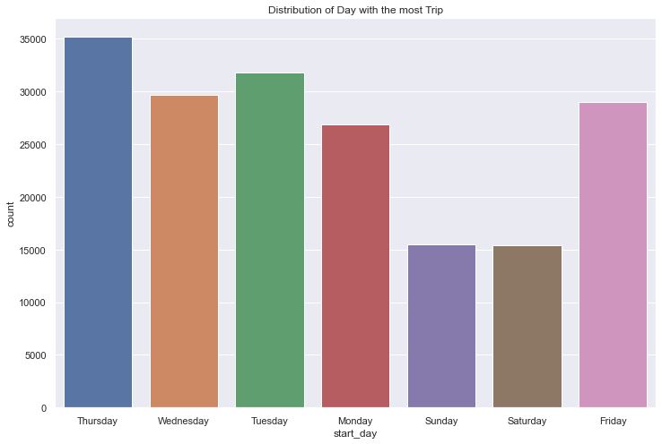

Both male and females age ranges have the same median age

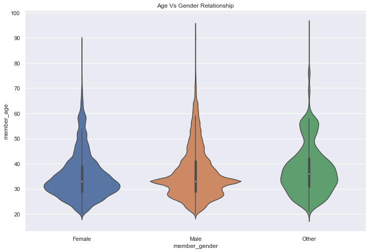

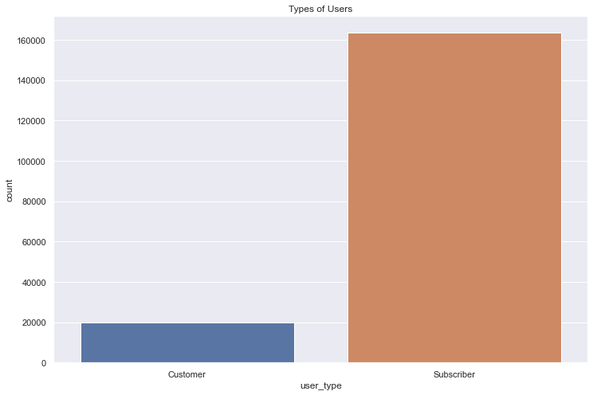

## Bivariate Data Analysis

> Similarly, in the bivariate process, I answer the following questions through visualizations of bar graph, histogram, boxplot and violinplot.
- Which day of the week has the most average trips duration?
- Which the trip duration of each age group?
- What isthe age range of different user types?
- What is the age range of different genders?

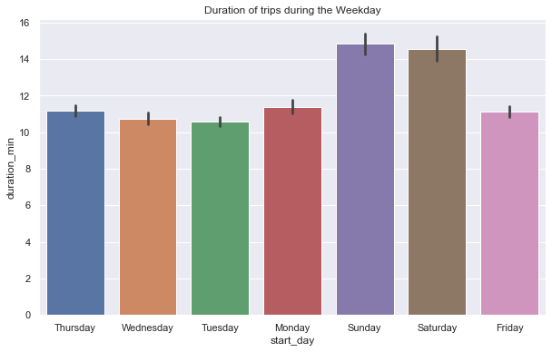

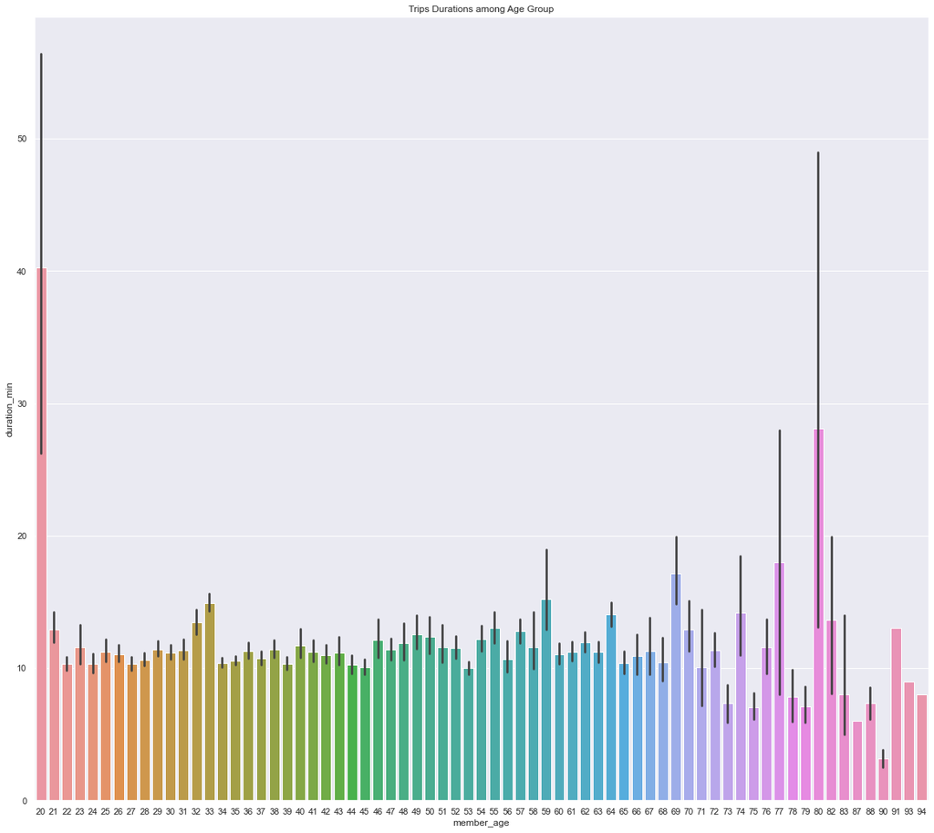

Most the customers are between the ages of 30 and 39. While the age range of majority of subscribers is 30 and 41 years.

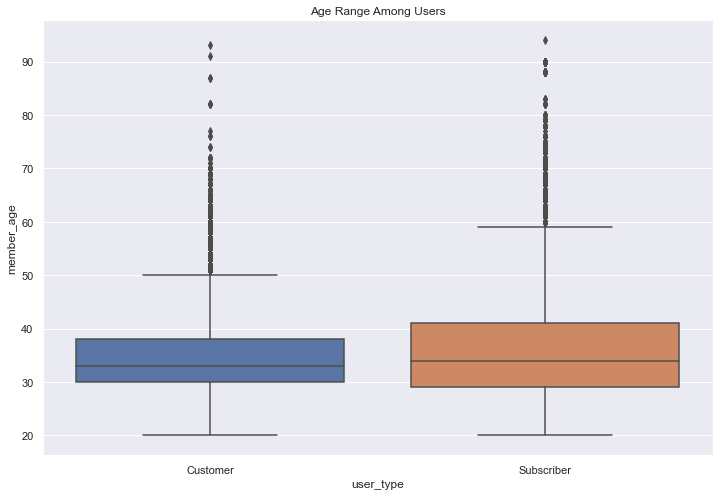

## Multivariate Data Analysis

> Likewise, with the multivariate analysis, I found answers to the following questions through visualizations of bar graph, histogram, boxplot violinplot:
> - What is the relationship between Weekdays, Average Duration and User Gender?
> - Which gender have the most average trip duration among weekdays?
> - Were there features that strengthened each other?
> - Which user_type and member_gender took the most trip?

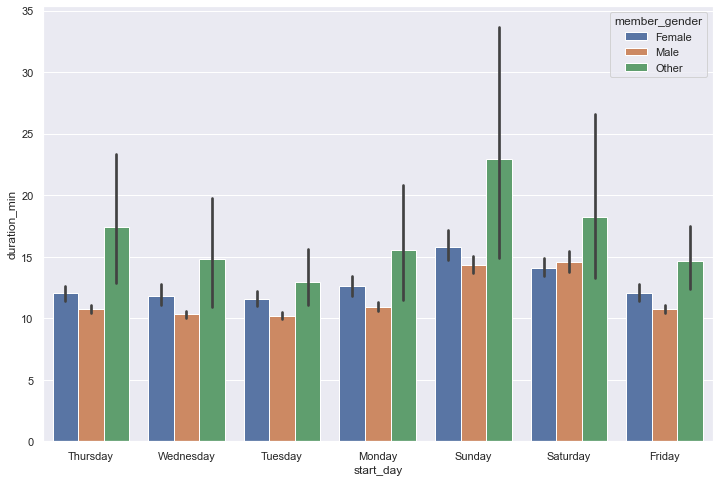

Both customer and subscribers show similar trends for age and trip duration. However, there is a slight increase in that of the subscribers.

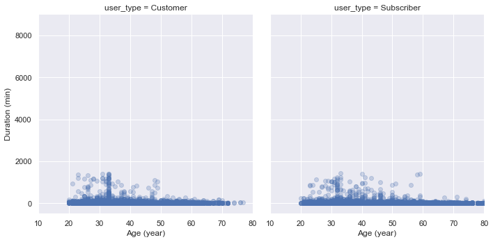

"Other" gender have the largest median accross board.

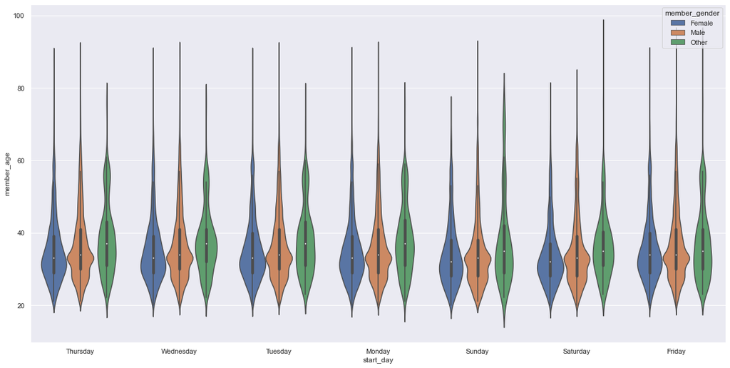

### Submission

If you are using classroom workspace, you can choose from the following two ways of submission:

1. **Submit from the workspace**. Make sure you have removed the example project from the /home/workspace directory. You must submit the following files:
   - Part_I_notebook.ipynb
   - Part_I_notebook.html or pdf
   - Part_II_notebook.ipynb
   - Part_I_slides.html
   - README.md
   - dataset (optional)
1. **Submit a zip file on the last page of this project lesson**. In this case, open the Jupyter terminal and run the command below to generate a ZIP file.

   ```
   zip -r my_project.zip .
   ```

   The command abobve will ZIP every file present in your /home/workspace directory. Next, you can download the zip to your local, and follow the instructions on the last page of this project lesson.